# Introduction to CorporaCoCo

2022-08-05

# Getting started

Load the library. This is available from [CRAN](https://cran.r-project.org/package=CorporaCoCo) and the latest development versions can be found on [GitHub](https://github.com/mahlberg-lab/CorporaCoCo).

```r
library(CorporaCoCo)
```

## corp_text

A passage from *Alice’s Adventures in Wonderland*:

```r
a <- "`But do cats eat bats, I wonder?' And here Alice began to get rather sleepy, and went on saying to herself, in a dreamy sort of way, `Do cats eat bats? Do cats eat bats?' and sometimes, `Do bats eat cats?' for, you see, as she couldn't answer either question, it didn't much matter which way she put it."
```

Create a `corp_text` object:

```r
a_text <- corp_text(a)
```

We used the default tokenization, so let’s look at the type mappings:

```r
corp_type_lookup(a_text)
#          type    tokens
#  1:         a         a
#  2:     alice     Alice
#  3:       and  And, and
#  4:    answer    answer
#  5:        as        as
#  6:      bats      bats
#  7:     began     began
#  8:       but       But
#  9:      cats      cats
# 10:  couldn't  couldn't
# 11:    didn't    didn't
# 12:        do    do, Do
# 13:    dreamy    dreamy
# 14:       eat       eat
# 15:    either    either
# 16:       for       for
# 17:       get       get
# 18:      here      here
# 19:   herself   herself
# 20:         i         I
# 21:        in        in
# 22:        it        it
# 23:    matter    matter
# 24:      much      much
# 25:        of        of
# 26:        on        on
# 27:       put       put
# 28:  question  question
# 29:    rather    rather
# 30:    saying    saying
# 31:       see       see
# 32:       she       she
# 33:    sleepy    sleepy
# 34: sometimes sometimes
# 35:      sort      sort
# 36:        to        to
# 37:       way       way
# 38:      went      went
# 39:     which     which
# 40:    wonder    wonder
# 41:       you       you
#          type    tokens
```

You can combine `corp_text` objects:

```r
aa <- "The cat sat on the mat."
bb <- "This dog ate this cat."
aaa <- corp_text(aa)
bbb <- corp_text(bb)
ccc <- list(aaa, bbb)
corp_text_rbindlist(ccc)
# $text
# [1] "The cat sat on the mat. This dog ate this cat."
#
# $tokens
#     idx type start end token
#  1:   1  the     1   3   The
#  2:   2  cat     5   7   cat
#  3:   3  sat     9  11   sat
#  4:   4   on    13  14    on
#  5:   5  the    16  18   the
#  6:   6  mat    20  22   mat
#  7:   7 this    25  28  This
#  8:   8  dog    30  32   dog
#  9:   9  ate    34  36   ate
# 10:  10 this    38  41  this
# 11:  11  cat    43  45   cat
#
# attr(,"class")
# [1] "corp_text"
# attr(,"PACKAGE_VERSION")
# [1] '2.0'
# attr(,"DATE")
# [1] "2022-08-05"
```

## corp_concordance

You can look at concordance lines using `corp_text` objects:

```r
corp_concordance(a_text, span = "4LR", nodes = c("eat"))
# [1]                       NA--- NANABut do cats eat bats, I wonder?' And --- here Alice began
# [2]          a dreamy sort --- of way, `Do cats eat bats? Do cats eat --- bats?' and sometimes
# [3]         way, `Do cats --- eat bats? Do cats eat bats?' and sometimes, `Do --- bats eat cats
# [4] cats eat bats?' --- and sometimes, `Do bats eat cats?' for, you see, --- as she couldn't
```

If you supply one or more `collocates`, they will be highlighted and act as a filter:

```r
# filtering for one collocate
y <- corp_concordance(a_text, span = "4LR", nodes = c("eat"), collocates = c("but"))
y
# [1] NA--- NANA*But* do cats eat bats, I wonder?' And --- here Alice began

# filtering for two collocates
y <- corp_concordance(a_text, span = "4LR", nodes = c("eat"), collocates = c("but", "and"))
y
# [1]                       NA--- NANA*But* do cats eat bats, I wonder?' *And* --- here Alice began
# [2]           way, `Do cats --- eat bats? Do cats eat bats?' *and* sometimes, `Do --- bats eat cats
# [3] cats eat bats?' --- *and* sometimes, `Do bats eat cats?' for, you see, --- as she couldn't
```

If you do not want the collocates to act as a filter, but you just want to highlight them in the full concordance, you can add `collocates` to the `print` function:

```r
# rerunning the original concordance without a collocate filter
o <- corp_concordance(a_text, span = "4LR", nodes = c("eat"))

# printing the concordance and adding collocate highlighting
print(o, collocates = c("but"))
# [1]                     NA--- NANA*But* do cats eat bats, I wonder?' And --- here Alice began
# [2]          a dreamy sort --- of way, `Do cats eat bats? Do cats eat --- bats?' and sometimes
# [3]         way, `Do cats --- eat bats? Do cats eat bats?' and sometimes, `Do --- bats eat cats
# [4] cats eat bats?' --- and sometimes, `Do bats eat cats?' for, you see, --- as she couldn't
```

Because a `corp_concordance` object is just a `data.table` you can sort it, filter it. So in the following example of a slightly longer concordance, we can demonstrate the sorting by 1. the node and 2. the first type to the right of the node (“R1_type” position):

```r
s <- corp_concordance(a_text, span = "4LR", nodes = c("cats", "bats"))
s[order(N, R1_type)]
# [1]          Do cats eat --- bats? Do cats eat bats?' and sometimes, `Do bats --- eat cats?' for
# [2]       dreamy sort of --- way, `Do cats eat bats? Do cats eat bats?' --- and sometimes, `Do
# [3]  Do cats eat --- bats?' and sometimes, `Do bats eat cats?' for, you --- see, as she
# [4]                      NA--- But do cats eat bats, I wonder?' And here --- Alice began to
# [5]                       NA--- NANANANABut do cats eat bats, I wonder?' --- And here Alice
# [6]           in a dreamy --- sort of way, `Do cats eat bats? Do cats --- eat bats?' and
# [7]          of way, `Do --- cats eat bats? Do cats eat bats?' and sometimes, `--- Do bats eat
# [8] eat bats?' and --- sometimes, `Do bats eat cats?' for, you see, as --- she couldn't answer
```

As with another `data.table`, you can also save the output to a csv file using `write.csv`, e.g. `write.csv(s, "concordance.csv")`.

You can sort the concordance using the *types* or the *tokens*:

```r
names(y)
#  [1] "idx"     "CL"      "L4"      "L3"      "L2"      "L1"      "N"       "R1"      "R2"
# [10] "R3"      "R4"      "CR"      "L4_type" "L3_type" "L2_type" "L1_type" "N_type"  "R1_type"
# [19] "R2_type" "R3_type" "R4_type" "_L4"     "_L3"     "_L2"     "_L1"     "_N"      "_R1"
# [28] "_R2"     "_R3"     "_R4"
```

and if you want to see the raw `data.table`:

```r
print(y, as_data_table = TRUE)
#    idx               CL   L4        L3 L2   L1   N   R1  R2        R3  R4               CR L4_type
# 1:   4             <NA> <NA>       But do cats eat bats   I    wonder And here Alice began    <NA>
# 2:  34   way, `Do cats   eat      bats Do cats eat bats and sometimes  Do    bats eat cats     eat
# 3:  40 cats eat bats?'   and sometimes Do bats eat cats for       you see  as she couldn't     and
#      L3_type L2_type L1_type N_type R1_type R2_type   R3_type R4_type  _L4 _L3 _L2 _L1 _N _R1 _R2
# 1:       but      do    cats    eat    bats       i    wonder     and <NA>                 ,
# 2:      bats      do    cats    eat    bats     and sometimes      do       ?             ?'
# 3: sometimes      do    bats    eat    cats     for       you     see      , `            ?'   ,
#    _R3 _R4
# 1: ?'
# 2: , `
# 3:      ,
```

## corp_surface

This works just like the old `surface` function but now you must pass it `corp_text` objects:

```r
a_cooccurs <- corp_surface(a_text, span = '1L1R', nodes = c("alice", "bats", "cats"))
```

By the way, if you do `corp_concordance` on a `corp_surface` object it will use the `span`, `nodes` and `collocates` values used to create the `corp_surface` object as the default values for `corp_concordance`:

```r
corp_concordance(a_cooccurs)
# [1]                      NA--- do  cats eat --- bats, I wonder
# [2]           But do cats --- eat  bats, I --- wonder?' And here
# [3]       I wonder?' And --- here Alice began --- to get rather
# [4]          sort of way, `--- Do  cats eat --- bats? Do cats
# [5]         way, `Do cats --- eat  bats? Do --- cats eat bats
# [6]         cats eat bats? --- Do  cats eat --- bats?' and sometimes
# [7]         bats? Do cats --- eat  bats?' and --- sometimes, `Do bats
# [8] bats?' and sometimes, `--- Do  bats eat --- cats?' for, you
# [9]   sometimes, `Do bats --- eat  cats?' for, --- you see, as
```

## corp_coco

The same passage after it has been translated into Finnish and back to English using Google translate:

```r
b <- "`But cats eat bats, I wonder?' And here, Alice began to get pretty sleepy and went on to say to herself, in a dreamlike way: `Are cats eating bats? Are cats eating bats?' And sometimes, `Do cats have to eat cats?' since you see because he could not answer the questions, he did not really matter how he put it."
b_text <- corp_text(b)

b_cooccurs <- corp_surface(b_text, span = '1L1R', nodes = c("alice", "bats", "cats"))
b_cooccurs
#         x      y H M
#  1: alice  began 1 1
#  2: alice   here 1 1
#  3:  bats    and 1 5
#  4:  bats    are 1 5
#  5:  bats    eat 1 5
#  6:  bats eating 2 4
#  7:  bats      i 1 5
#  8:  cats    are 2 8
#  9:  cats    but 1 9
# 10:  cats     do 1 9
# 11:  cats    eat 2 8
# 12:  cats eating 2 8
# 13:  cats   have 1 9
# 14:  cats  since 1 9
```

```r
cats_and_bats <- corp_coco(a_cooccurs, b_cooccurs, nodes = c("alice", "bats", "cats"), fdr = 1.0)
```

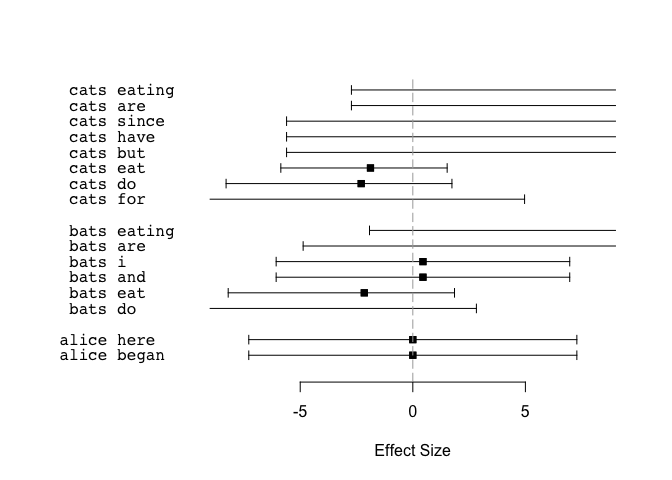

```r
plot(cats_and_bats)
```

## Complex types

Looks like their is a difference for *cats* and *bats* but the text is small so we have no power. Let’s have a look at the tokenization:

```r
corp_type_lookup(a_text)
#          type    tokens
#  1:         a         a
#  2:     alice     Alice
#  3:       and  And, and
#  4:    answer    answer
#  5:        as        as
#  6:      bats      bats
#  7:     began     began
#  8:       but       But
#  9:      cats      cats
# 10:  couldn't  couldn't
# 11:    didn't    didn't
# 12:        do    do, Do
# 13:    dreamy    dreamy
# 14:       eat       eat
# 15:    either    either
# 16:       for       for
# 17:       get       get
# 18:      here      here
# 19:   herself   herself
# 20:         i         I
# 21:        in        in
# 22:        it        it
# 23:    matter    matter
# 24:      much      much
# 25:        of        of
# 26:        on        on
# 27:       put       put
# 28:  question  question
# 29:    rather    rather
# 30:    saying    saying
# 31:       see       see
# 32:       she       she
# 33:    sleepy    sleepy
# 34: sometimes sometimes
# 35:      sort      sort
# 36:        to        to
# 37:       way       way
# 38:      went      went
# 39:     which     which
# 40:    wonder    wonder
# 41:       you       you
#          type    tokens
```

Since *cats* and *bats* are both types of mammals maybe we can look at the co-occurences with *mammals*:

```r
a_tokens <- corp_get_tokens(a_text)
b_tokens <- corp_get_tokens(b_text)

a_tokens$type <- sub("^(cats|bats)$", "MAMMALS", a_tokens$type)
b_tokens$type <- sub("^(cats|bats)$", "MAMMALS", b_tokens$type)

a_text_mammals <- corp_text(a, tokens = a_tokens)
# Warning: 'tokens': the 'idx' and 'token' columns are being recalculated
b_text_mammals <- corp_text(b, tokens = b_tokens)
# Warning: 'tokens': the 'idx' and 'token' columns are being recalculated
```

So now we have a new type to token mapping:

```r
corp_type_lookup(a_text_mammals)
#          type     tokens
#  1:   MAMMALS cats, bats
#  2:         a          a
#  3:     alice      Alice
#  4:       and   And, and
#  5:    answer     answer
#  6:        as         as
#  7:     began      began
#  8:       but        But
#  9:  couldn't   couldn't
# 10:    didn't     didn't
# 11:        do     do, Do
# 12:    dreamy     dreamy
# 13:       eat        eat
# 14:    either     either
# 15:       for        for
# 16:       get        get
# 17:      here       here
# 18:   herself    herself
# 19:         i          I
# 20:        in         in
# 21:        it         it
# 22:    matter     matter
# 23:      much       much
# 24:        of         of
# 25:        on         on
# 26:       put        put
# 27:  question   question
# 28:    rather     rather
# 29:    saying     saying
# 30:       see        see
# 31:       she        she
# 32:    sleepy     sleepy
# 33: sometimes  sometimes
# 34:      sort       sort
# 35:        to         to
# 36:       way        way
# 37:      went       went
# 38:     which      which
# 39:    wonder     wonder
# 40:       you        you
#          type     tokens
```

and so:

```r
a_cooccurs_mammals <- corp_surface(a_text_mammals, span = '1L1R', nodes = c("alice", "MAMMALS"))
b_cooccurs_mammals <- corp_surface(b_text_mammals, span = '1L1R', nodes = c("alice", "MAMMALS"))

mammals <- corp_coco(a_cooccurs_mammals, b_cooccurs_mammals, nodes = c("alice", "MAMMALS"), fdr = 1.0)
```

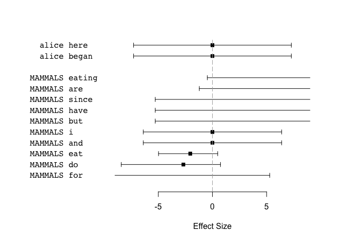

```r
plot(mammals)
```